# Project 1 Predictive Modeling

# Introduction

During this project, we will analyse two data sets in order to obtain more insights about them and predict some objective variable. First, we will approach the problem with a Linear Regression model, then, with the second data set, we will try to model a Generalised Linear Model. These are the data sets used:

- Airbnb: https://www.kaggle.com/datasets/dipeshkhemani/airbnb-cleaned-europe-dataset
- Data scientist jobs: https://www.kaggle.com/datasets/nikhilbhathi/data-scientist-salary-us-glassdoor

```r
#Adding the necessary libraries
library(tidyverse)
library(MASS)
library(caret)
```

```r
library(e1071)
library(ggplot2)
library(effects)
library(sjPlot)
```

# A. Linear Regression

## 1. Data preparation

For the first part of the assignment we will be using the Airbnb data set. It consist of information about the Airbnb stays in some European cities. The variables are the following:

- City: Amsterdam, Athens, Barcelona, Berlin, Budapest, Lisbon, Paris, Rome or Vienna
- Price: continuous numeric variable
- Day: WeekDay or Weekend
- Room Type: Entire home/apt, Private room or Shared room
- Shared Room: binary variable
- Private Room: binary variable
- Person capacity: integer from 2 to 6.
- Superhost: binary variable
- Multiple Rooms: binary variable
- Business: binary variable
- Cleanliness Rating: integer from 2 to 10.
- Guest satisfaction: continuous numeric variable
- Bedrooms: integer from 0 to 10
- City center(km): continuous numeric variable
- Metro distance(km): continuous numeric variable
- Attraction index: continuous variable measuring the attraction to the Airbnb by the costumers
- Normalised Atraction index: same but normalised
- Restraunt Index: continuous variable measuring the restaurant performance index
- Normalised Restraunt Index: same but normalised

### 1.1. Objective variable and split

The goal would be to predict the Price variable in terms of the others. First, it is always a good idea to split from the beginning the training set (what the tool is going to see) from the testing set (used only to validate predictions).

```r
par(mar = c(2, 2, 2, 2))
# Loading and preparing data
Airbnb <- read.csv("Airbnb_data.csv")
```

```r
#we set seed for reproducibility
set.seed(123)

# split between training and testing sets
spl = createDataPartition(Airbnb$Price, p = 0.8, list = FALSE)  # 80% for training

AirbnbTrain = Airbnb[spl,]
AirbnbTest = Airbnb[-spl,]

str(AirbnbTrain)
```

```
## 'data.frame':    33373 obs. of  19 variables:
##  $ City                       : chr  "Amsterdam" "Amsterdam" "Amsterdam" "Amsterdam" ...
##  $ Price                      : num  194 344 264 434 486 ...
##  $ Day                        : chr  "Weekday" "Weekday" "Weekday" "Weekday" ...
##  $ Room.Type                  : chr  "Private room" "Private room" "Private room" "Private room" ...
##  $ Shared.Room                : chr  "False" "False" "False" "False" ...
##  $ Private.Room               : chr  "True" "True" "True" "True" ...
##  $ Person.Capacity            : num  2 4 2 4 2 2 4 4 2 2 ...
##  $ Superhost                  : chr  "False" "False" "False" "False" ...
##  $ Multiple.Rooms             : int  1 0 0 0 0 0 0 0 1 0 ...
##  $ Business                   : int  0 0 1 1 0 0 0 0 0 0 ...
##  $ Cleanliness.Rating         : num  10 8 9 9 10 10 10 9 10 10 ...
##  $ Guest.Satisfaction         : num  93 85 87 90 98 94 100 96 88 96 ...
##  $ Bedrooms                   : int  1 1 1 2 1 1 3 2 1 1 ...
##  $ City.Center..km.           : num  5.023 0.488 5.748 0.385 0.545 ...
##  $ Metro.Distance..km.        : num  2.539 0.239 3.652 0.44 0.319 ...
##  $ Attraction.Index           : num  78.7 631.2 75.3 493.3 552.8 ...
##  $ Normalised.Attraction.Index: num  4.17 33.42 3.99 26.12 29.27 ...
##  $ Restraunt.Index            : num  98.3 837.3 95.4 875 815.3 ...
##  $ Normalised.Restraunt.Index : num  6.85 58.34 6.65 60.97 56.81 ...
```

### 1.2. Null values

Once separated, let’s clean and understand the training set. First, we check any missing values. There is any missing value.

```r
any(is.na(AirbnbTrain))
```

```
## [1] FALSE
```

### 1.3. Numerical variables

On the following steps we would be analyzing more deeply each variable by it’s type. We would start with the numerical variables, showing some statistics such as minnimum, maximum, quantiles mean and median.

```r
summary(AirbnbTrain)
```

```
##      City               Price              Day             Room.Type
##  Length:33373       Min.   :   34.78   Length:33373       Length:33373
##  Class :character   1st Qu.:  144.02   Class :character   Class :character
##  Mode  :character   Median :  203.80   Mode  :character   Mode  :character
##                     Mean   :  259.75
##                     3rd Qu.:  297.37
##                     Max.   :18545.45
##  Shared.Room        Private.Room       Person.Capacity  Superhost
##  Length:33373       Length:33373       Min.   :2.000   Length:33373
##  Class :character   Class :character   1st Qu.:2.000   Class :character
##  Mode  :character   Mode  :character   Median :3.000   Mode  :character
##                                        Mean   :3.237
##                                        3rd Qu.:4.000
##                                        Max.   :6.000
##  Multiple.Rooms      Business      Cleanliness.Rating Guest.Satisfaction
##  Min.   :0.0000   Min.   :0.0000   Min.   : 2.000     Min.   : 20.00
##  1st Qu.:0.0000   1st Qu.:0.0000   1st Qu.: 9.000     1st Qu.: 90.00
##  Median :0.0000   Median :0.0000   Median :10.000     Median : 95.00
##  Mean   :0.2956   Mean   :0.3406   Mean   : 9.443     Mean   : 93.08
##  3rd Qu.:1.0000   3rd Qu.:1.0000   3rd Qu.:10.000     3rd Qu.: 98.00
##  Max.   :1.0000   Max.   :1.0000   Max.   :10.000     Max.   :100.00
##     Bedrooms      City.Center..km.   Metro.Distance..km. Attraction.Index
##  Min.   : 0.000   Min.   : 0.01504   Min.   : 0.002301   Min.   :  15.15
##  1st Qu.: 1.000   1st Qu.: 1.26893   1st Qu.: 0.237353   1st Qu.: 124.77
##  Median : 1.000   Median : 2.24310   Median : 0.392646   Median : 230.48
##  Mean   : 1.167   Mean   : 2.67974   Mean   : 0.605518   Mean   : 294.29
##  3rd Qu.: 1.000   3rd Qu.: 3.58272   3rd Qu.: 0.678831   3rd Qu.: 395.24
##  Max.   :10.000   Max.   :25.28456   Max.   :14.273577   Max.   :4512.60
##  Normalised.Attraction.Index Restraunt.Index   Normalised.Restraunt.Index
##  Min.   :  0.9263            Min.   :  19.58   Min.   :  0.6407
##  1st Qu.:  5.5428            1st Qu.: 210.75   1st Qu.: 11.1718
##  Median :  9.9684            Median : 521.53   Median : 21.8874
##  Mean   : 11.7366            Mean   : 628.04   Mean   : 25.6456
##  3rd Qu.: 15.4820            3rd Qu.: 861.52   3rd Qu.: 36.9084
##  Max.   :100.0000            Max.   :6696.16   Max.   :100.0000
```

From the data obtained we can obtain the following insigths.

- **Price** : The maximum of price seems to be too large for the mean and median. We can get a better look with a boxplot.

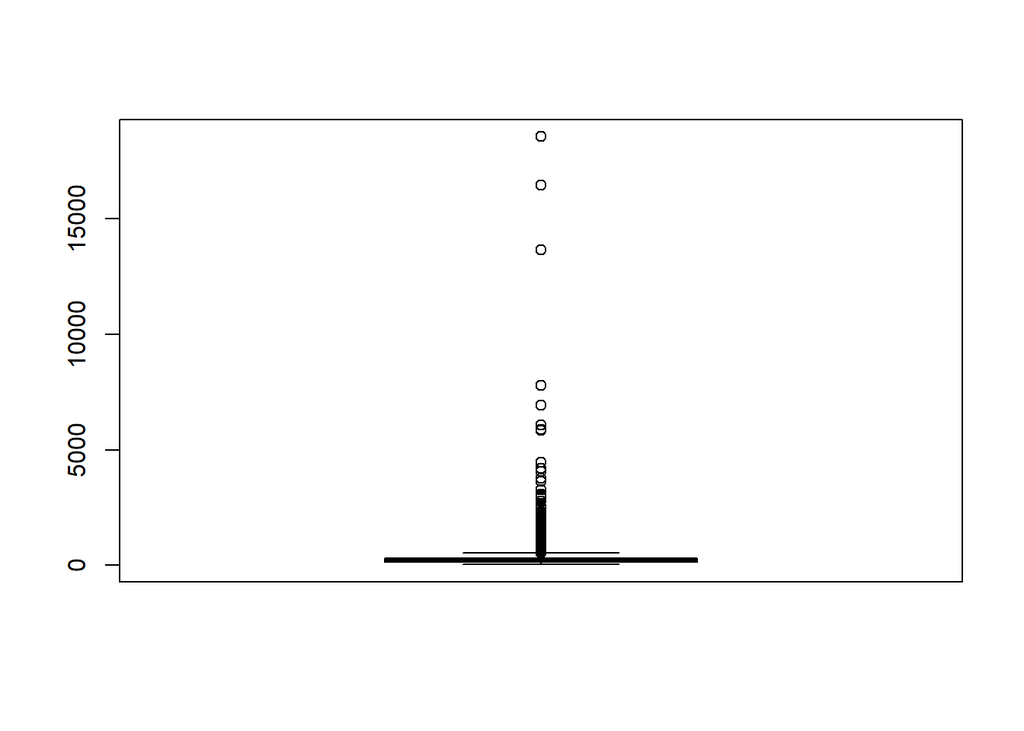

```r
boxplot(AirbnbTrain$Price)
```

Although the maximum is an outlier, it is not alone, as we can observe many other outliers that could be representing expensive Airbnb. In the case the maximum would be alone, we could get rid of it, but in this case this can be meaningful data.

- **Attraction.Index and Restraunt.Index**: as we have the normalize columns, we have redundant information, so we will only keep those.

```r
AirbnbTrain <- subset(AirbnbTrain, select = -c(Attraction.Index, Restraunt.Index ))
```

The rest of numerical variables seem fine with their ranges, so no changes are needed.

### 1.4. Categorical variables

Let’s now evaluate the categorical variables.

```r
table(AirbnbTrain$City)
```

```
##
## Amsterdam    Athens Barcelona    Berlin  Budapest    Lisbon     Paris      Rome
##      1696      4243      2274      2003      3185      4621      5340      7219
##    Vienna
##      2792
```

```r
table(AirbnbTrain$Day)
```

```
##
## Weekday Weekend
##   16752   16621
```

```r
table(AirbnbTrain$Room.Type)
```

```
##
## Entire home/apt    Private room     Shared room
##           22580           10546             247
```

```r
table(AirbnbTrain$Shared.Room)
```

```
##
## False  True
## 33126   247
```

```r
table(AirbnbTrain$Private.Room)
```

```
##
## False  True
## 22827 10546
```

```r
table(AirbnbTrain$Superhost)
```

```
##
## False  True
## 24022  9351
```

```r
table(AirbnbTrain$Multiple.Rooms)
```

```
##
##     0     1
## 23507  9866
```

```r
table(AirbnbTrain$Business)
```

```
##
##     0     1
## 22005 11368
```

The variable ‘Room type’ has the same information than ‘Private Room’ and ‘Shared room’, so we will erase the last two.

```r
AirbnbTrain <- subset(AirbnbTrain, select = -c(Private.Room, Shared.Room ))
```

Finally, the variable ‘Superhost’ is as False/True, we will code as binary the False/True options.

```r
AirbnbTrain$Superhost<-as.numeric(as.logical(AirbnbTrain$Superhost))
```

## 2. Explanatory Data Analysis

### 2.1. Objective variable distribution

In order to better comprehend our data, we need to plot it. Concretely, we will have in mind plots respect to the objective variable, the price, for trying to visualize a model for predicting it.

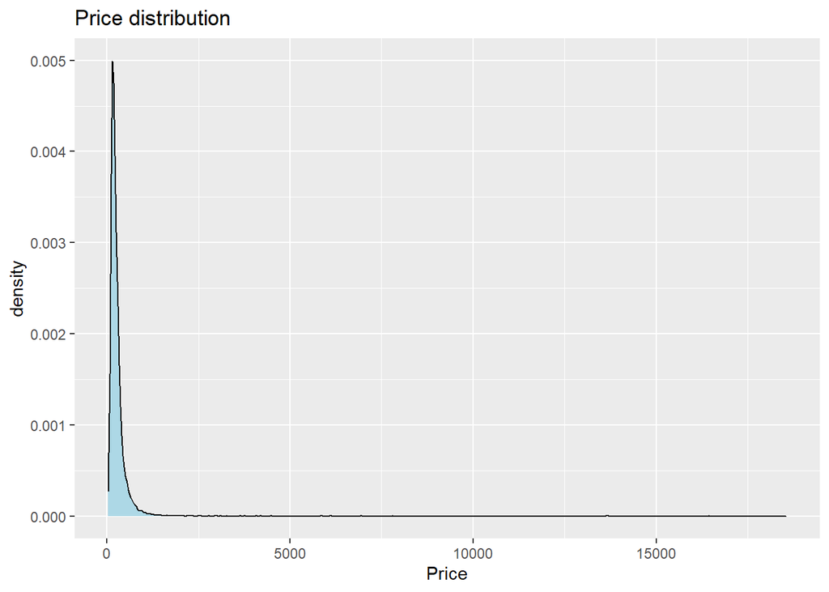

```r
ggplot(AirbnbTrain, aes(Price)) + geom_density(fill="lightblue") + xlab("Price") + ggtitle("Price distribution")
```

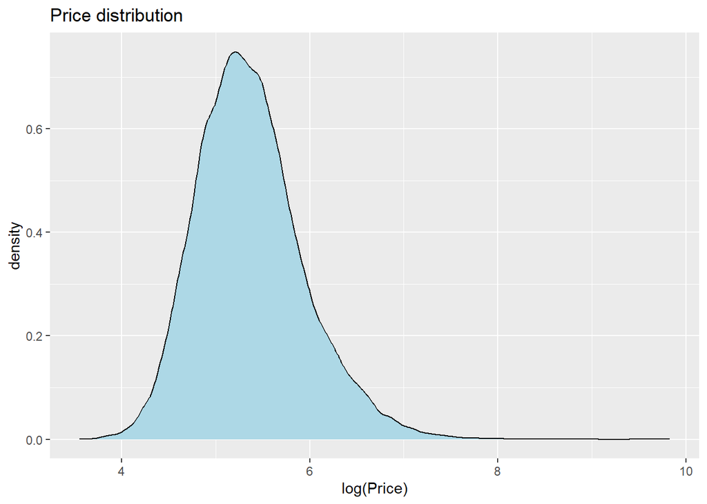

```r
## from the statistics obtained before we know price has no 0 values as minimum is 34, so we can apply the logarithm to get a better distribution

ggplot(AirbnbTrain, aes(log(Price))) + geom_density(fill="lightblue") + xlab("log(Price)") + ggtitle("Price distribution")
```

```r
mean(log(AirbnbTrain$Price))
```

```
## [1] 5.366296
```

```r
exp(mean(log(AirbnbTrain$Price)))
```

```
## [1] 214.0685
```

### 2.2. Relations between objective and rest of variables

After observing the response variable individually, we can approximate some regressions with plots. We now have in mind the prices in terms of the city, in order to better understand the data.

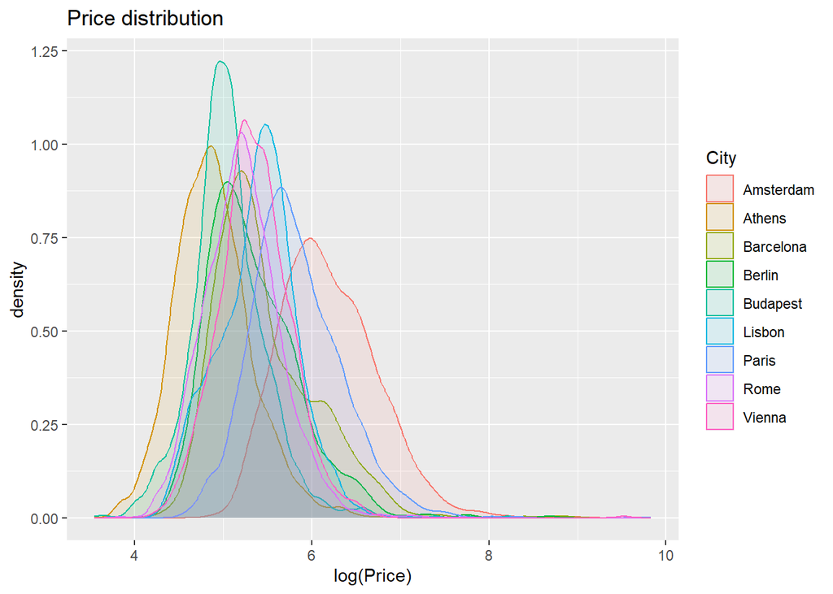

```r
ggplot(AirbnbTrain, aes(log(Price))) + geom_density(aes(group=City, colour=City, fill=City), alpha=0.1) + ggtitle("Price distribution")
```

Some of the variables that we may think are important to determine the price of an Airbnb are: distance to metro, distance to city center, number of bedrooms, restaurant and attraction indexes. Let’s observe them.

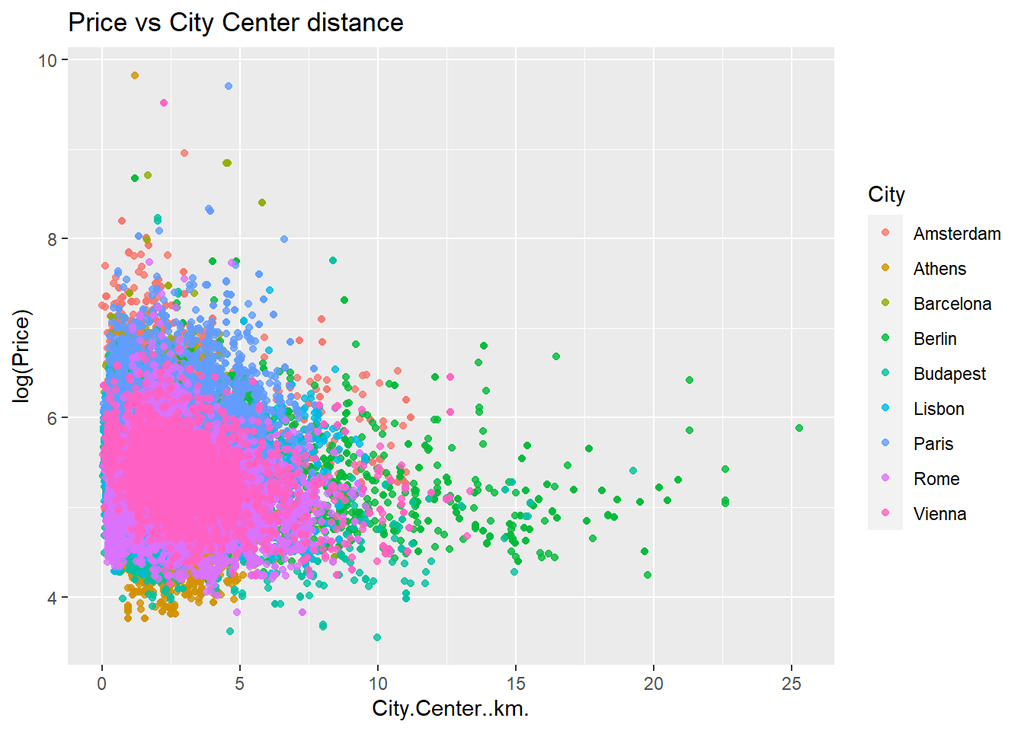

```r
ggplot(AirbnbTrain, aes(x=City.Center..km., y=log(Price), color=City)) + geom_point(alpha=0.8) + ggtitle("Price vs City Center distance")
```

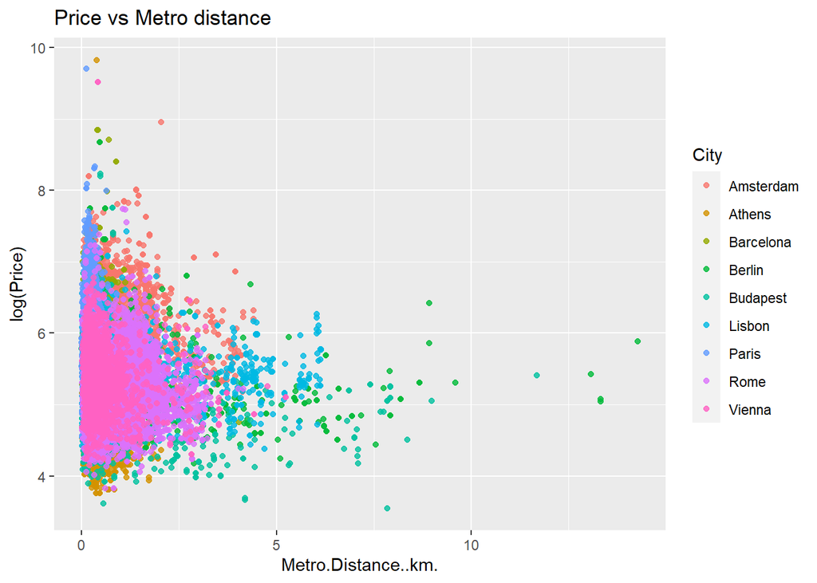

```r
ggplot(AirbnbTrain, aes(x=Metro.Distance..km., y=log(Price), color=City)) + geom_point(alpha=0.8) + ggtitle("Price vs Metro distance")
```

As observed, the most expensive Airbnb are the ones really close to the metro and center (there are no points at the right upper corner).

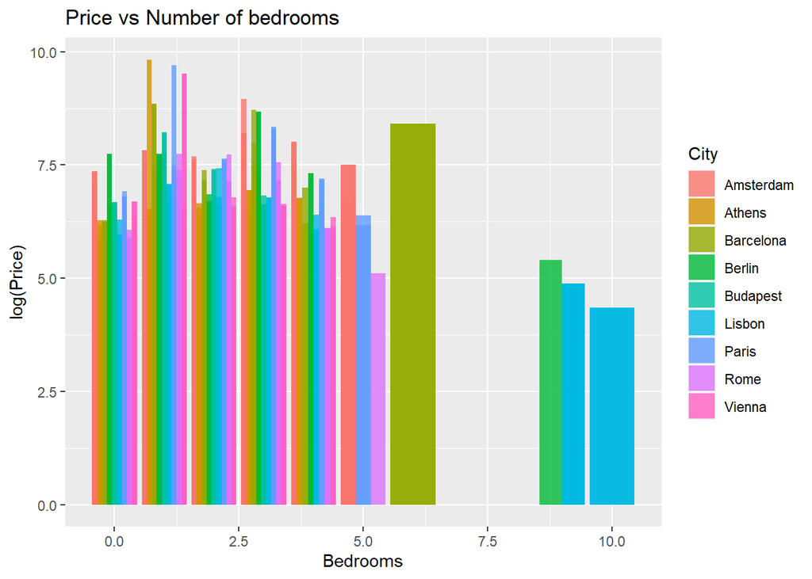

```r
ggplot(AirbnbTrain, aes(x = Bedrooms, y = log(Price), fill = City)) +
  geom_bar(stat = "identity", position = "dodge", alpha = 0.8) +
  ggtitle("Price vs Number of bedrooms")
```

```r
table(AirbnbTrain$Bedrooms)
```

```
##
##     0     1     2     3     4     5     6     9    10
##  2983 23055  6245  1017    56     7     2     6     2
```

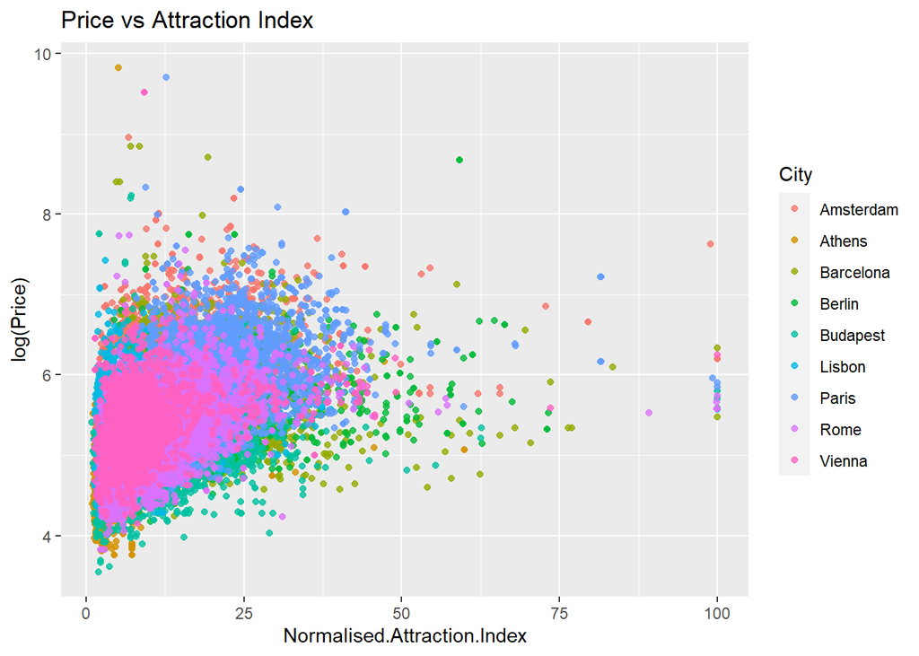

```r
ggplot(AirbnbTrain, aes(x=Normalised.Attraction.Index, y=log(Price), color=City)) + geom_point(alpha=0.8) + ggtitle("Price vs Attraction Index")
```

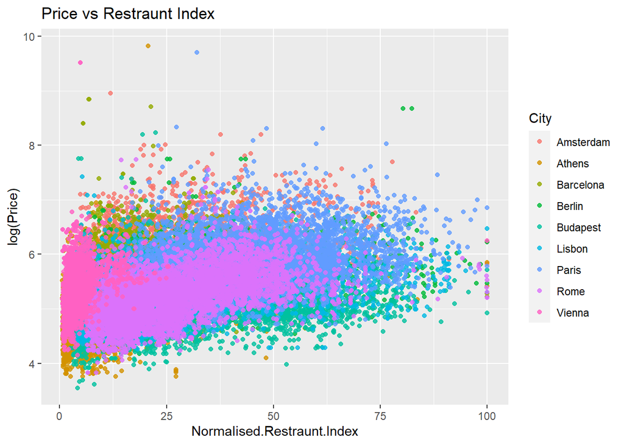

```r
ggplot(AirbnbTrain, aes(x=Normalised.Restraunt.Index, y=log(Price), color=City)) + geom_point(alpha=0.8) + ggtitle("Price vs Restraunt Index")
```

Finally, the indexes did not provide as much information. But, focusing on the Restaurant index we could visualize a kind of linear tendency with lower prices on the ones with lower index and higher prices close to higher index rating. However, is still difficult to make assumptions without an apropiatte model. In the following sections this relationship would be better explained.

### 2.3. Correlations

The most important term when evaluating a data set for predictions are the correlations. Which are the variables that are more correlated with our objective variable? First, we would focus on isolated correlations.

```r
## Moving the objective function to the last position
AirbnbTrain<-AirbnbTrain[, c(1:(2 - 1), (2 + 1):ncol(AirbnbTrain), 2)]
```

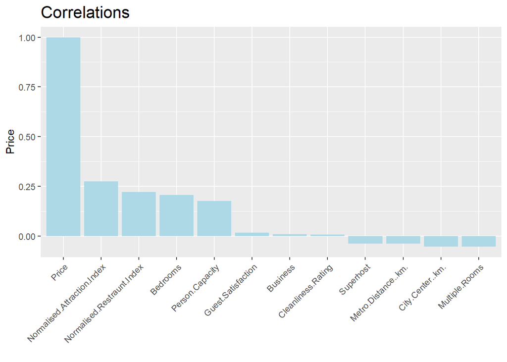

```r
corr_delay <- sort(cor(AirbnbTrain[,c(4:15)])["Price",], decreasing = T)
corr=data.frame(corr_delay)
ggplot(corr,aes(x = row.names(corr), y = corr_delay)) +
  geom_bar(stat = "identity", fill = "lightblue") +
  scale_x_discrete(limits= row.names(corr)) +
  labs(x = "", y = "Price", title = "Correlations") +
  theme(plot.title = element_text(hjust = 0, size = rel(1.5)),
        axis.text.x = element_text(angle = 45, hjust = 1))
```

A priori, the only variables helpful for performing a linear regression predictor are ‘Normalised Atraction Index’, ‘Normalised Restraunt Index’, ‘number of Bedrooms’ and ‘Person Capacity’. However, is important to recall that we are plotting the individual correlations, maybe if we add information between variables we could get higher correlations, and therefore have better predictions.

## 3. Model development

### 3.1. Simple linear regression: interpreting the betas

Before developing a complex model for prediction, we will try to create a simpler one where we avoid colinearities and better understand the betas. Therefore, we first create a simple linear regresor with the higher correlation variable: ‘Normalised Atraction Index’.

```r
simple_linFit <- lm(log(Price) ~ Normalised.Attraction.Index, data=AirbnbTrain)
summary(simple_linFit)
```

```
##
## Call:
## lm(formula = log(Price) ~ Normalised.Attraction.Index, data = AirbnbTrain)
##
## Residuals:
##     Min      1Q  Median      3Q     Max
## -2.5942 -0.3499 -0.0404  0.2918  4.6656
##
## Coefficients:
##                              Estimate Std. Error t value Pr(>|t|)
## (Intercept)                 5.0064211  0.0048131 1040.16   <2e-16 ***
## Normalised.Attraction.Index 0.0306625  0.0003338   91.85   <2e-16 ***
## ---
## Signif. codes:  0 '***' 0.001 '**' 0.01 '*' 0.05 '.' 0.1 ' ' 1
##
## Residual standard error: 0.5107 on 33371 degrees of freedom
## Multiple R-squared:  0.2018, Adjusted R-squared:  0.2018
## F-statistic:  8436 on 1 and 33371 DF,  p-value: < 2.2e-16
```

The simple linear regression model is defined as: $log(Price) = \beta_0 + \beta_1 N.Attraction.Index= 5.01 + 0.03 N.Attraction.Index$

where $\beta_1$ explains that a 1 unit increase in the normalized attraction index would increase in 0.03 % the log of the Price. We can trust this model because the information gain is larger than the noise, as the p_value close to 0 confirms.

Furthermore, focusing on the global information, the residual standard error, although is larger than the local, is still not that high. The residual standard error is higher than the local because there is not much information gain from the model, however, we can trust the model as the information that $\beta_1$ gives us has small standard error.

Finally, the $R^2$ tell us about the information gain we get from the model. Almost 20%, while the remaining 80% is noise. In general, this is a difficult application, as the most correlated variable is only giving us 20% of the information, so it would be difficult to obtain high $R^2$ values on the test set. However, we always need to compare with a benchmark for better conclusions (on the following sections).

To better comprehend how this model approaches the price prediction we will plot the regression line:

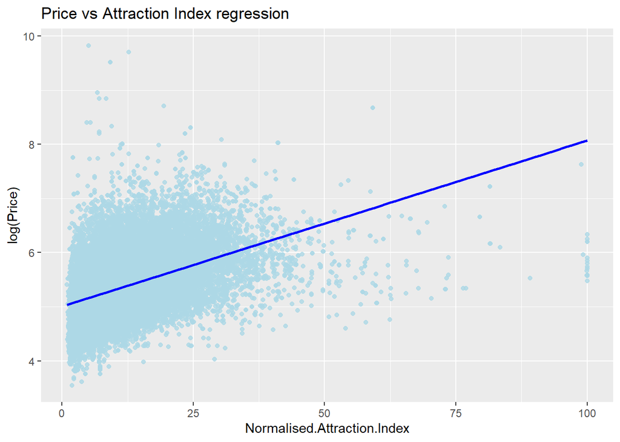

```r
# Scatter plot

ggplot(AirbnbTrain, aes(x = Normalised.Attraction.Index, y = log(Price))) +
  geom_point(alpha = 0.8, color= 'lightblue') +
  geom_smooth(method = "lm", se = FALSE, color = "blue") +
  ggtitle("Price vs Attraction Index regression")
```

After understanding the model, let’s evaluate how it predicts (this result will be later compared with the benchmark and the complex linear regression model).

```r
pred_simple= exp(predict(simple_linFit, newdata= AirbnbTest))

#Let's know validate the predictions, calculating R^2 in the testing set

R2_simple= cor(pred_simple, log(AirbnbTest$Price))^2
R2_simple
```

```
## [1] 0.06822481
```

As expected, $R^2$ on the testing set is smaller than on the training set (remember it was 0.2). Always is more difficult to predict future values than present ones.

Finally, we can perform some diagnosis of our simple model to obtain more conclusions:

- Residuals vs Fitted Values: this plot show as how our model is not homoscedastic, that is, the variance of the residuals is not constant with the Price, but it increases (negatively) for higher prices. This can be explained by the non symmetric distribution and the outliers.
- Q-Q Residuals: the residuals are not normally distributed, as the outliers in the tails of the plot suggest issues with extreme residuals.
- Scale-Location Plot: again this plots confirm us our model is not homocedastic, as there is a clear deviation on the line.

In general, we can say our model is not good for our objective.

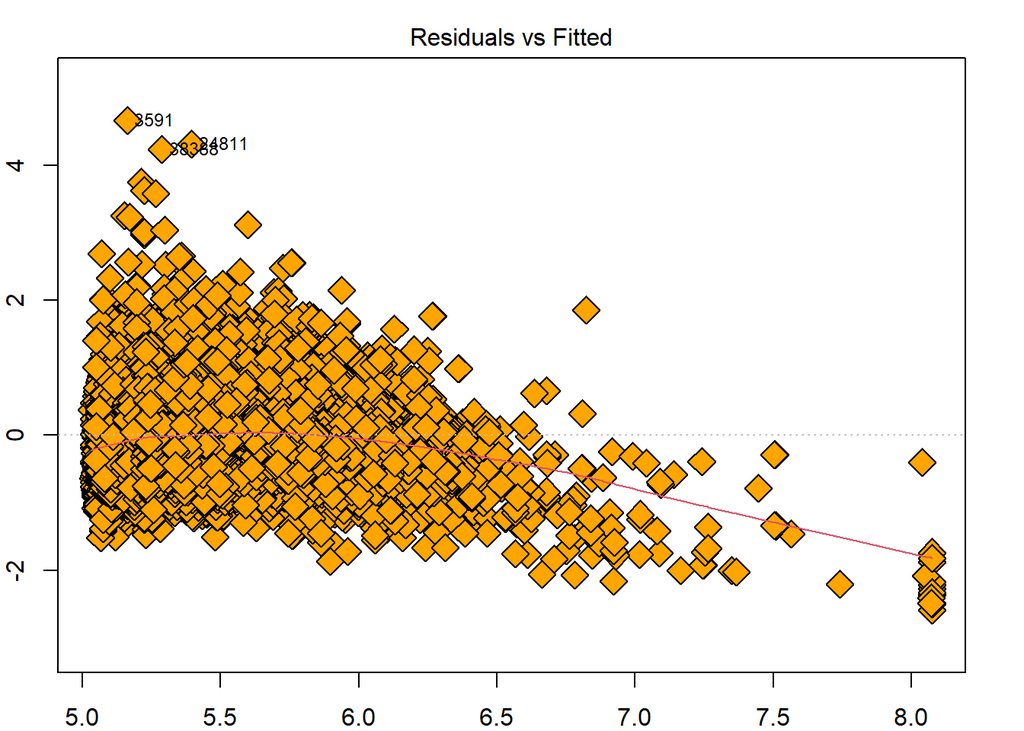

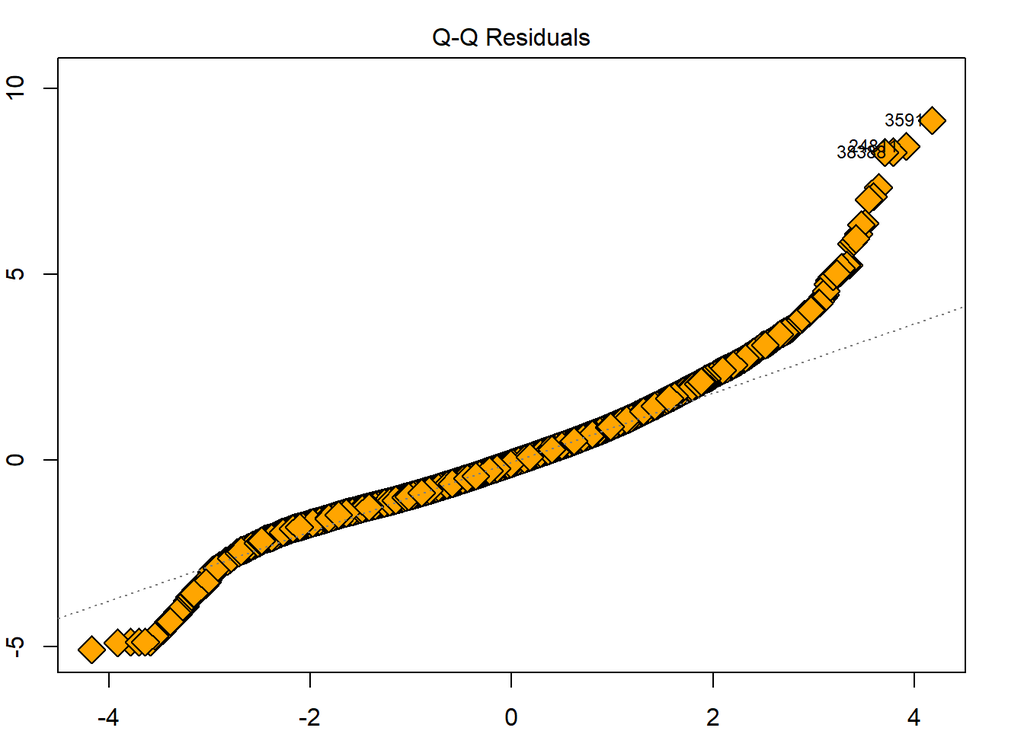

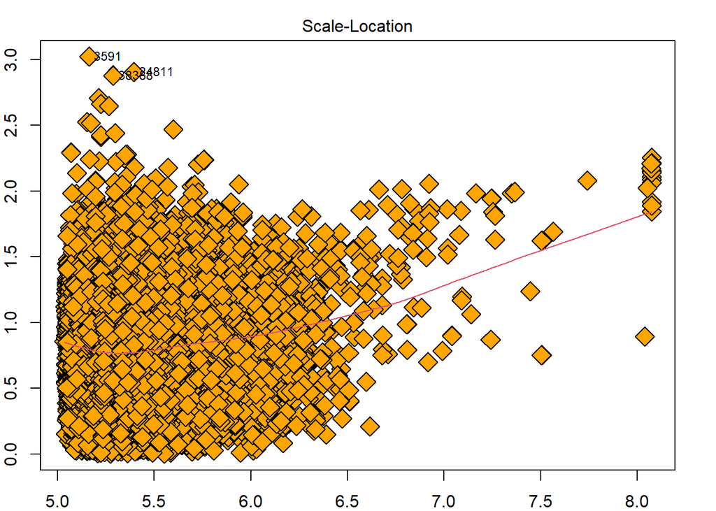

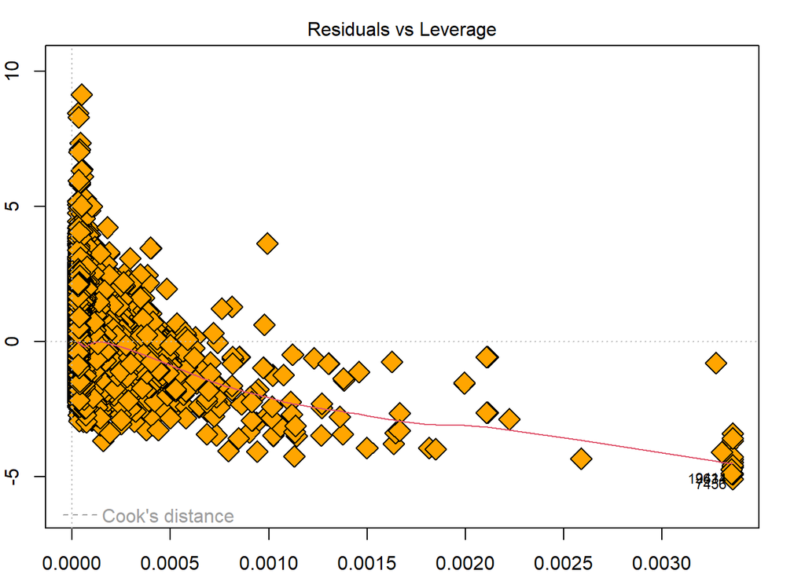

```r
par(mar = c(2, 2, 2, 2))

plot(simple_linFit, pch=23 ,bg='orange',cex=2)
```

### 3.2. Benchmark

After understanding better how our data is constructed and being defined a simple regression model, we will know try to develop the best model for prediction. But first, we need to define the benchmark, from where we have to improve.

In our case, as we are dealing with numerical continuous target, we would consider the benchmark as predicting the mean (again using the logarithmic transformation). This would be similar to the following model: $log(price)= \beta_0 \times 1$

```r
benchFit <- lm(log(Price) ~ 1, data=AirbnbTrain)
pred_bench <- exp(predict(benchFit, newdata=AirbnbTest))
```

As on the mean predictor the $R^2$ can not be computed, we will use the Root Mean Squared Error for comparison:

```r
#MSE comparison: my model vs benchmark
RMSE_simple=sqrt(mean((pred_simple - log(AirbnbTest$Price))^2))
RMSE_bench= sqrt(mean((pred_bench - log(AirbnbTest$Price))^2))
RMSE_simple
```

```
## [1] 245.3246
```

```r
RMSE_bench
```

```
## [1] 208.6998
```

Clearly, our simple model is worse than the naive model, so we need to improve it.

### 3.3. Complex model (without interactions)

As a first approach to find our perfect model, we would fit a model with all the variables we have. To do it, we first must change the format of the variable ‘Superhost’ on the test set for non finding programatic errors when calculating the predictions.

```r
AirbnbTest$Superhost<-as.numeric(as.logical(AirbnbTest$Superhost))
```

```r
all_linFit <- lm(log(Price) ~ ., data=AirbnbTrain)

# Predict on the test set
pred_all <- exp(predict(all_linFit, newdata = AirbnbTest))

  # Calculate MSE
RMSE_all <- sqrt(mean((pred_all - AirbnbTest$Price)^2))
R2_all= cor(pred_all, AirbnbTest$Price)^2
summary(all_linFit)
```

```
##
## Call:
## lm(formula = log(Price) ~ ., data = AirbnbTrain)
##
## Residuals:
##     Min      1Q  Median      3Q     Max
## -1.7074 -0.2150 -0.0346  0.1745  4.9825
##
## Coefficients:
##                               Estimate Std. Error  t value Pr(>|t|)
## (Intercept)                  5.1716909  0.0265461  194.819  < 2e-16 ***
## CityAthens                  -1.3972970  0.0107985 -129.398  < 2e-16 ***
## CityBarcelona               -0.5914761  0.0112139  -52.745  < 2e-16 ***
## CityBerlin                  -0.7640333  0.0119535  -63.917  < 2e-16 ***
## CityBudapest                -1.3315474  0.0105828 -125.822  < 2e-16 ***
## CityLisbon                  -0.8724677  0.0103285  -84.472  < 2e-16 ***
## CityParis                   -0.4990992  0.0102839  -48.532  < 2e-16 ***
## CityRome                    -1.0169906  0.0093397 -108.889  < 2e-16 ***
## CityVienna                  -0.8176160  0.0111826  -73.115  < 2e-16 ***
## DayWeekend                   0.0349568  0.0036725    9.519  < 2e-16 ***
## Room.TypePrivate room       -0.3485847  0.0050047  -69.651  < 2e-16 ***
## Room.TypeShared room        -0.8604851  0.0215593  -39.913  < 2e-16 ***
## Person.Capacity              0.0863816  0.0019911   43.385  < 2e-16 ***
## Superhost                    0.0191439  0.0043569    4.394 1.12e-05 ***
## Multiple.Rooms               0.0420003  0.0047026    8.931  < 2e-16 ***
## Business                     0.1223397  0.0047741   25.626  < 2e-16 ***
## Cleanliness.Rating           0.0370638  0.0028742   12.896  < 2e-16 ***
## Guest.Satisfaction           0.0012763  0.0003191    4.000 6.34e-05 ***
## Bedrooms                     0.1372091  0.0036008   38.105  < 2e-16 ***
## City.Center..km.            -0.0111994  0.0014347   -7.806 6.06e-15 ***
## Metro.Distance..km.          0.0140646  0.0031524    4.462 8.16e-06 ***
## Normalised.Attraction.Index  0.0122973  0.0003749   32.805  < 2e-16 ***
## Normalised.Restraunt.Index   0.0032318  0.0001920   16.830  < 2e-16 ***
## ---
## Signif. codes:  0 '***' 0.001 '**' 0.01 '*' 0.05 '.' 0.1 ' ' 1
##
## Residual standard error: 0.3335 on 33350 degrees of freedom
## Multiple R-squared:  0.6598, Adjusted R-squared:  0.6596
## F-statistic:  2940 on 22 and 33350 DF,  p-value: < 2.2e-16
```

```r
R2_all
```

```
## [1] 0.3008916
```

```r
RMSE_all
```

```
## [1] 239.6521
```

First, if we compare the $R^2$ values in the training and in the testing sets with the simple model, before we had 0.2 and 0.068, respectively. The value for the training set has increased until 0.66 by using all the variables, and the value on the testing set has increased on until 0.3. Of course, this complex model is better than the simpler one.

However, when comparing with the RMSE, we can see how the simple model has the worst score with 245, followed by the complex with 239, and again the benchmark is the best one with 208.

In order to try to improve this metrics, now we need to take into account interactions between variables.

### 3.4. Complex model (with interactions)

We first start by doing some feature selection, as does not have any sense to add all the features because we will be adding more noise. Therefore, we would try to find the best combination of the most correlated variables: ‘Normalised.Attraction.Index’, ‘Normalised.Restraunt.Index’, ‘Bedrooms’ and ‘Person.Capacity’. In order to do it, we will focus on both the $R^2$ and the MSE, trying to find the model that best maximizes the first one while minimasing the second one.

```r
Y <- log(AirbnbTrain$Price)

variables_to_add= list("Normalised.Attraction.Index", "Normalised.Restraunt.Index", "Bedrooms", "Person.Capacity")

#variables_to_add= list( "Bedrooms", "Person.Capacity", "Normalised.Attraction.Index", "Normalised.Restraunt.Index")

#variables_to_add= list("Bedrooms", "Normalised.Attraction.Index", "Normalised.Restraunt.Index",  "Person.Capacity")

#variables_to_add= list("Person.Capacity", "Normalised.Attraction.Index", "Normalised.Restraunt.Index", "Bedrooms" )

# Create an empty data frame to store models,R2 and RMSE
rmse_df <- data.frame(RMSE = numeric(length(variables_to_add)), R2= numeric(length(variables_to_add)), Variables = character(length(variables_to_add)), stringsAsFactors = FALSE)

models <- list()

# Fit models and calculate MSE
for (i in seq_along(variables_to_add)) {
  formula <- as.formula(paste("Y ~ ", paste(variables_to_add[1:i], collapse = " + ")))
  model <- lm(formula, data = AirbnbTrain)

  # Store the model
  models[[i]] <- model

  # Predict on the test set
  pred <- exp(predict(model, newdata = AirbnbTest))

  # Calculate MSE
  rmse <- sqrt(mean((pred - log(AirbnbTest$Price))^2))

  R2= cor(pred, log(AirbnbTest$Price))^2

  # Store MSE and variables in the data frame
  rmse_df[i, "RMSE"] <- rmse
  rmse_df[i, "R2"] <- R2
  rmse_df[i, "Variables"] <- paste(variables_to_add[1:i], collapse = ", ")
}

# Find the model with the lowest MSE
best_model_index <- which.min(rmse_df$RMSE)
best_model <- models[[best_model_index]]

# Print results
cat("Best model includes variables:", rmse_df$Variables[best_model_index], "\n")
```

```
## Best model includes variables: Normalised.Attraction.Index, Normalised.Restraunt.Index
```

```r
cat("RMSE of the best model:", rmse_df$MSE[best_model_index], "\n")
```

```
## RMSE of the best model:
```

```r
cat("R2 of the best model:", rmse_df$R2[best_model_index], "\n")
```

```
## R2 of the best model: 0.12769
```

```r
rmse_df
```

| RMSE | R2 | Variables |
| --- | --- | --- |
| 245.3246 | 0.06822481 | Normalised.Attraction.Index |
| 232.1685 | 0.12768996 | Normalised.Attraction.Index, Normalised.Restraunt.Index |
| 246.4637 | 0.16277580 | Normalised.Attraction.Index, Normalised.Restraunt.Index, Bedrooms |
| 247.6407 | 0.19576589 | Normalised.Attraction.Index, Normalised.Restraunt.Index, Bedrooms, Person.Capacity |

After trying several combinations, we lead to the conclusion that, although adding the ‘Bedrooms’ and ‘Person.Capacity’ variables may increase the $R^2$, meaning is adding information, it also adds noise as the RMSE increases a lot. By the RMSE the best model is the one with only the first two variables (the ones more correlated), but we will choose to add also Bedrooms so $R^2$ is bigger enough.

```r
best_linFit <- lm(log(Price) ~ City*(Normalised.Attraction.Index + Normalised.Restraunt.Index)^2 + sqrt(Bedrooms) , data=AirbnbTrain)

# Predict on the test set
pred_best <- exp(predict(best_linFit, newdata = AirbnbTest))

  # Calculate MSE
RMSE_best <- sqrt(mean((pred_best - log(AirbnbTest$Price))^2))
R2_best= cor(pred, log(AirbnbTest$Price))^2
R2_best
```

```
## [1] 0.1957659
```

```r
RMSE_best
```

```
## [1] 272.4953
```

For better conclusions we can perform some diagnosis. Contrary to the simple model, this one has achieved to be more homocedastic, having constant variance of the residuals and better distribution in general.

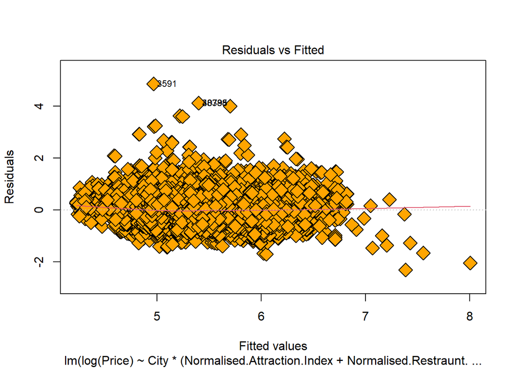

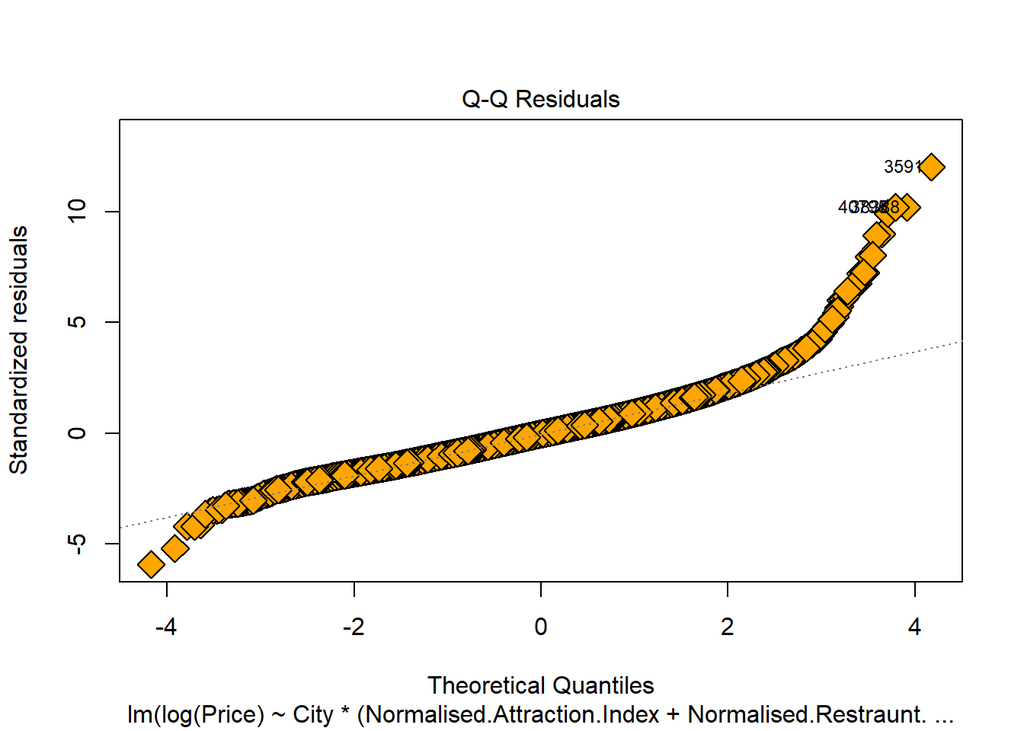

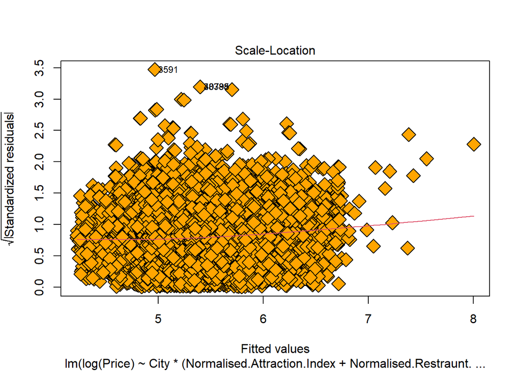

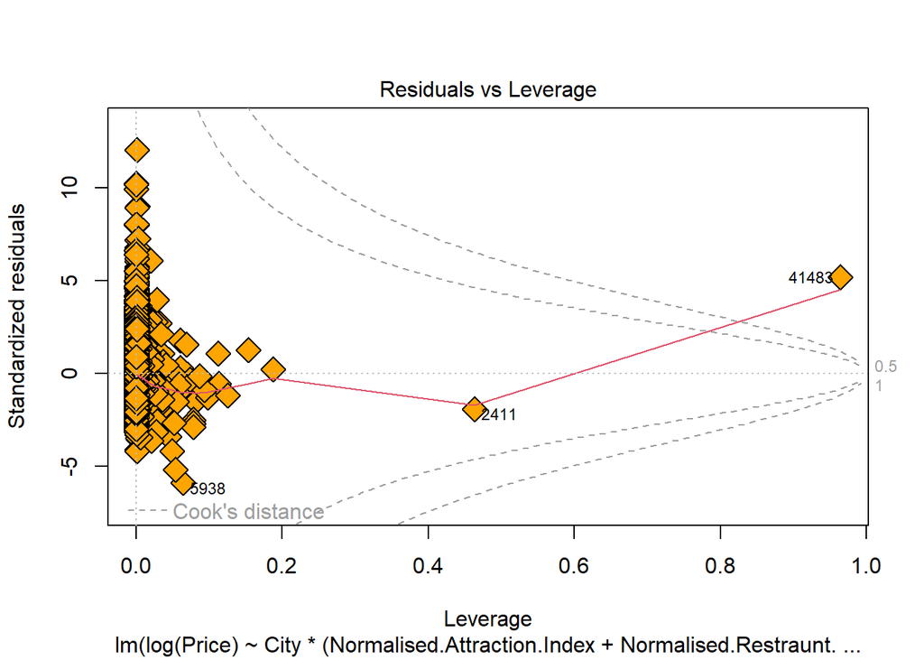

```r
plot(best_linFit, pch=23 ,bg='orange',cex=2)
```

### 3.5. Predictive performance and prediction Intervals

Finally, we would evaluate the predictions of our final model with the prediction intervals.

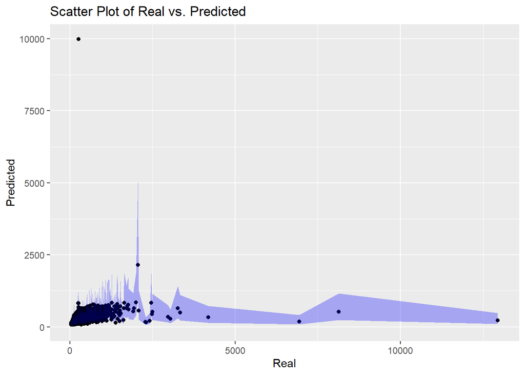

```r
pred_best <- predict(best_linFit, newdata = AirbnbTest, interval='prediction')

y = AirbnbTest$Price
yhat = exp(pred_best)

# Assuming pred.log contains the lower and upper prediction intervals
AirbnbTest$Pred = exp(pred_best[, "fit"])
AirbnbTest$Real = y
AirbnbTest$Lower = exp(pred_best[, "lwr"])
AirbnbTest$Upper = exp(pred_best[, "upr"])

# Create a data frame for plotting
plot_data <- data.frame(Real = AirbnbTest$Real,
                        Pred = AirbnbTest$Pred,
                        Lower = AirbnbTest$Lower,
                        Upper = AirbnbTest$Upper)
# Prediction Interval Plot

y_limits <- c(0, 10005)
ggplot(plot_data, aes(x = Real, y = Pred)) +
  geom_point() +
  geom_ribbon(aes(ymin = Lower, ymax = Upper), alpha = 0.3, fill = "blue") +
  labs(title = "Scatter Plot of Real vs. Predicted",
       x = "Real",
       y = "Predicted")+
  coord_cartesian(ylim = y_limits)
```

As we can observe, most of the points lies inside the shadow of the prediction intervals. To better evaluate the exact quantity we can count them.

```r
# Counting the points outside the intervals
outside_interval_count <- sum(AirbnbTest$Real < AirbnbTest$Lower | AirbnbTest$Real > AirbnbTest$Upper)

# Calculating the coverage
total_points <- nrow(AirbnbTest)
coverage <- round(100-(outside_interval_count / total_points) * 100, digits=1)

# Printing the coverage
print(paste("Percentage of points inside the intervals:", coverage, "%"))
```

```
## [1] "Percentage of points inside the intervals: 95.5 %"
```

Finally, our model is covering 95.5 % of the points inside the prediction intervals. That is, although before we determined that our predictions were not that accurate due to bad results on RMSE, we can say that our model is useful, as we are capturing well the noise. In general, is more important to focus the performance of a model on the intervals that on exact predictions, as usually we are interested on knowing a close value of the price, but not interested on the exact one.

# B. Generalised Linear Models

## 1. Data preparation

Continuing with the second dataset, we will focus on predicting the average salary offered on several job postings related to the position of Data Scientist, by fitting a Generalised Linear Model.

```r
Salary_data <- read.csv("Data_Analyst_Jobs.csv")
```

### 1.1. Objective variable and split

First, we split on training and test, and evaluate the type of the variables.

```r
set.seed(123)

# split between training and testing sets
spl = createDataPartition(Salary_data$Sector, p = 0.8, list = FALSE)  # 80% for training
Salary_data_Train = Salary_data[spl,]
Salary_data_Test = Salary_data[-spl,]

str(Salary_data_Train)
```

```
## 'data.frame':    605 obs. of  42 variables:
##  $ index             : int  0 1 2 3 4 8 10 15 17 18 ...
##  $ Job.Title         : chr  "Data Scientist" "Healthcare Data Scientist" "Data Scientist" "Data Scientist" ...
##  $ Salary.Estimate   : chr  "$53K-$91K (Glassdoor est.)" "$63K-$112K (Glassdoor est.)" "$80K-$90K (Glassdoor est.)" "$56K-$97K (Glassdoor est.)" ...
##  $ Job.Description   : chr  "Data Scientist\nLocation: Albuquerque, NM\nEducation Required: Bachelor’s degree required, preferably in math, "| __truncated__ "What You Will Do:\n\nI. General Summary\n\nThe Healthcare Data Scientist position will join our Advanced Analyt"| __truncated__ "KnowBe4, I…
##  $ Rating            : num  3.8 3.4 4.8 3.8 2.9 3.3 3.5 3.6 4.3 4.2 ...
##  $ Company.Name      : chr  "Tecolote Research\n3.8" "University of Maryland Medical System\n3.4" "KnowBe4\n4.8" "PNNL\n3.8" ...
##  $ Location          : chr  "Albuquerque, NM" "Linthicum, MD" "Clearwater, FL" "Richland, WA" ...
##  $ Headquarters      : chr  "Goleta, CA" "Baltimore, MD" "Clearwater, FL" "Richland, WA" ...
##  $ Size              : chr  "501 - 1000 " "10000+ " "501 - 1000 " "1001 - 5000 " ...
##  $ Founded           : int  1973 1984 2010 1965 1998 2014 2011 1995 2011 2010 ...
##  $ Type.of.ownership : chr  "Company - Private" "Other Organization" "Company - Private" "Government" ...
##  $ Industry          : chr  "Aerospace & Defense" "Health Care Services & Hospitals" "Security Services" "Energy" ...
##  $ Sector            : chr  "Aerospace & Defense" "Health Care" "Business Services" "Oil, Gas, Energy & Utilities" ...
##  $ Revenue           : chr  "$50 to $100 million (USD)" "$2 to $5 billion (USD)" "$100 to $500 million (USD)" "$500 million to $1 billion (USD)" ...
```

[output cut: 28 more lines]

The objective variable would be ‘Avg.Salary.K’, that is an already cleaned variable from ‘Salary.Estimate’, measuring the mean of the salaries offer in thousands of dollars. Therefore, we could get rid of this last variable.

Apart from this one, we could observe several other variables that are already clean on another column, as ‘Company.Name’ and ‘company_txt’, ‘Job.Title’ and ‘job_title_sim’, and finally, ‘Location’ and ‘Job.Location’.

Other variables we would eliminate are the ‘Job.Description’, as is a natural language column that would not gives as any valuable information. Similarly, index is not giving any information so would be also eliminated.

Finally, ‘Lower.Salary’ and ‘Upper.Salary’ would be erased as they can easily predict the objective variable by performing the mean of the two, so would be useless to develop a complete model if they alone can predict it.

```r
Salary_data_Train <- subset(Salary_data_Train, select = -c(Job.Description, Job.Title, Location, index, Salary.Estimate, Lower.Salary, Upper.Salary, Company.Name ))
```

### 1.2. Categorical variables

With the remaining features, we need to evaluate the null values per each type, starting with the categorical. Although it can seem there is none, is because they are set as ‘na’ or ‘-1’. Columns with value -1 means either the data scraping was unsuccessful for that or the data was not present. Therefore, we would evaluate the classes of the features to observe if the null values comprehend a significant quantity.

```r
any(is.na(Salary_data_Train))
```

```
## [1] FALSE
```

```r
#We comment the variables where there are many categories to avoid a long notebook

#table(Salary_data_Train$Headquarters)
table(Salary_data_Train$Size)
```

```
##
##       1 - 50        10000+   1001 - 5000     201 - 500  5001 - 10000
##            26            99           128            98            59
##   501 - 1000      51 - 200        unknown
##           113            74             8
```

```r
#table(Salary_data_Train$Type.of.ownership)
#table(Salary_data_Train$Industry )
table(Salary_data_Train$Sector )
```

```
##
##                                 -1                 Accounting & Legal
##                                  8                                  1
##                Aerospace & Defense             Agriculture & Forestry
##                                 20                                  1
##   Arts, Entertainment & Recreation          Biotech & Pharmaceuticals
##                                  4                                 90
##                  Business Services Construction, Repair & Maintenance
##                                 78                                  3
##                  Consumer Services                          Education
##                                  4                                 19
##                            Finance                         Government
##                                 34                                  9
##                        Health Care             Information Technology
##                                 40                                144
##                          Insurance                      Manufacturing
##                                 56                                 28
##                              Media                    Mining & Metals
##                                  5                                  3
##                         Non-Profit       Oil, Gas, Energy & Utilities
##                                  8                                 12
##                        Real Estate                             Retail
##                                  7                                 12
##                 Telecommunications         Transportation & Logistics
##                                  5                                  7
##                   Travel & Tourism
##                                  7
```

We can observe some null values on these first set of features, but not as much to be considered significant. However, we observe the variable ‘Headquarters’ has too many unique categories, which would not be helpful for developing the model, therefore we decided to remove it.

```r
Salary_data_Train <- subset(Salary_data_Train, select = -Headquarters)
```

The following variables ‘Industry’ and ‘Sector’ represents the same term, so we would only keep the one with less unique values.

```r
length(unique(Salary_data_Train$Industry))
```

```
## [1] 60
```

```r
length(unique(Salary_data_Train$Sector))
```

```
## [1] 25
```

We keep the ‘Sector’ one.

```r
Salary_data_Train <- subset(Salary_data_Train, select = -Industry)
```

```r
table(Salary_data_Train$Revenue)
```

```
##
##           $1 to $2 billion (USD)           $1 to $5 million (USD)
##                               48                                4
##         $10 to $25 million (USD)               $10+ billion (USD)
##                               27                               91
##       $100 to $500 million (USD)           $2 to $5 billion (USD)
##                               68                               36
##         $25 to $50 million (USD)          $5 to $10 billion (USD)
##                               35                               15
##          $5 to $10 million (USD)        $50 to $100 million (USD)
##                               16                               34
## $500 million to $1 billion (USD)       Less than $1 million (USD)
##                               52                                3
##         Unknown / Non-Applicable
##                              176
```

```r
#table(Salary_data_Train$Competitors)
#table(Salary_data_Train$company_txt )
```

```r
Salary_data_Train <- subset(Salary_data_Train, select = -c(Competitors, company_txt))
```

```r
#table(Salary_data_Train$Job.Location)
#table(Salary_data_Train$job_title_sim)
table(Salary_data_Train$seniority_by_title)
```

```
##
##  jr  na  sr
##   3 427 175
```

```r
table(Salary_data_Train$Degree)
```

```
##
##   M  na   P
## 199 317  89
```

For the same reason, ‘seniority_by_title’ and ‘Degree’ are also removed.

```r
Salary_data_Train <- subset(Salary_data_Train, select = -c(seniority_by_title,Degree))
```

### 1.3. Binary variables

This dataset, apart from many categorical variables, has also many binary ones. Most of them refer to skills required or not for the job offer, and others represent if salary was reported in hourly rate or if salary was provided by the employer. Let’s observe how they look to detect some unbalanced classes or not.

```r
table(Salary_data_Train$Hourly) # 1: If salary was reported in hourly rate. 0: Otherwise
```

```
##
##   0   1
## 585  20
```

```r
table(Salary_data_Train$Employer.provided) # 1: If the salary was provided by the employer 0: Otherwise
```

```
##
##   0   1
## 590  15
```

```r
# 1: If x skill is required 0: Otherwise

table(Salary_data_Train$Python)
```

```
##
##   0   1
## 284 321
```

```r
table(Salary_data_Train$spark)
```

```
##
##   0   1
## 469 136
```

```r
#table(Salary_data_Train$aws)
#table(Salary_data_Train$excel)
#table(Salary_data_Train$sql)
#table(Salary_data_Train$sas)
#table(Salary_data_Train$keras)
#table(Salary_data_Train$pytorch)
#table(Salary_data_Train$scikit)
#table(Salary_data_Train$tensor)
#table(Salary_data_Train$hadoop)
#table(Salary_data_Train$tableau)
#table(Salary_data_Train$bi)
#table(Salary_data_Train$flink)
#table(Salary_data_Train$mongo)
#table(Salary_data_Train$google_an) #1: If Google analytics certificate is required 0: Otherwise
```

Most of them are kind of unbalanced, but they may be helpful for the matter of hand. So, as there is no null values, we would keep all of them.

### 1.4. Numeric variables

```r
Salary_data_Train <- subset(Salary_data_Train, select = -Founded)
```

We first observe how many null values (-1) there are. As is not significant, we keep all.

```r
table(Salary_data_Train$Rating) # It gives the rating of the company
```

```
##
##  -1 1.9 2.1 2.2 2.3 2.4 2.5 2.6 2.7 2.8 2.9   3 3.1 3.2 3.3 3.4 3.5 3.6 3.7 3.8
##   9   3   4   2   2   6   2  11  12   6  14  13  19  31  33  35  37  33  50  51
## 3.9   4 4.1 4.2 4.3 4.4 4.5 4.6 4.7 4.8   5
##  52  41   8  23  30  30   6   8  22   8   4
```

```r
#table(Salary_data_Train$Age) # Age of the company (in yrs)
#table(Salary_data_Train$Avg.Salary.K.)
```

Next, we evaluate some metrics to better understand all of them.

```r
summary(Salary_data_Train$Rating) # It gives the rating of the company
```

```
##    Min. 1st Qu.  Median    Mean 3rd Qu.    Max.
##  -1.000   3.300   3.700   3.615   4.000   5.000
```

```r
summary(Salary_data_Train$Age) # Age of the company (in yrs)
```

```
##    Min. 1st Qu.  Median    Mean 3rd Qu.    Max.
##    -1.0    12.0    25.0    46.4    60.0   277.0
```

```r
summary(Salary_data_Train$Avg.Salary.K.)
```

```
##    Min. 1st Qu.  Median    Mean 3rd Qu.    Max.
##    15.5    73.0    96.0   100.7   122.0   254.0
```

As observed, ‘Age’ and ‘Rating’ minimum value is -1, but this is not representative as this refers to null values. Furthermore, we can observe how our objective variable does not have any null or 0 values, which would be helpful for developing the model.

### 1.5. Final dataset

With all of the preprocessing, the training data finally looks like this.

```r
Salary_data_Train
```

|  | Rating | Size | Type.of.ownership | Sector | Revenue | Hourly | Employer.provided | Avg.Salary.K. | Job.Location | Age | Python | spark | aws | excel | sql | sas | keras | pytorch | scikit | tensor | hadoop | tableau | bi | flink | mongo | google_an | job_title_sim |
| --- | --- | --- | --- | --- | --- | --- | --- | --- | --- | --- | --- | --- | --- | --- | --- | --- | --- | --- | --- | --- | --- | --- | --- | --- | --- | --- | --- |
| 1 | 3.8 | 501 - 1000 | Company - Private | Aerospace & Defense | $50 to $100 million (USD) | 0 | 0 | 72.0 | NM | 48 | 1 | 0 | 0 | 1 | 0 | 1 | 0 | 0 | 0 | 0 | 0 | 1 | 1 | 0 | 0 | 0 | data scientist |
| 2 | 3.4 | 10000+ | Other Organization | Health Care | $2 to $5 billion (USD) | 0 | 0 | 87.5 | MD | 37 | 1 | 0 | 0 | 0 | 0 | 0 | 0 | 0 | 0 | 0 | 0 | 0 | 0 | 0 | 0 | 0 | data scientist |
| 3 | 4.8 | 501 - 1000 | Company - Private | Business Services | $100 to $500 million (USD) | 0 | 0 | 85.0 | FL | 11 | 1 | 1 | 0 | 1 | 1 | 1 | 0 | 0 | 0 | 0 | 0 | 0 | 0 | 0 | 0 | 0 | data scientist |
| 4 | 3.8 | 1001 - 5000 | Government | Oil, Gas, Energy & Utilities | $500 million to $1 billion (USD) | 0 | 0 | 76.5 | WA | 56 | 1 | 0 | 0 | 0 | 0 | 0 | 0 | 0 | 0 | 0 | 0 | 0 | 0 | 0 | 0 | 0 | data scientist |
| 5 | 2.9 | 51 - 200 | Company - Private | Business Services | Unknown / Non-Applicable | 0 | 0 | 114.5 | NY | 23 | 1 | 0 | 0 | 1 | 1 | 1 | 0 | 0 | 0 | 0 | 0 | 0 | 0 | 0 | 0 | 0 | data scientist |
| 9 | 3.3 | 10000+ | Hospital | Health Care | $500 million to $1 billion (USD) | 0 | 0 | 61.0 | NY | 7 | 0 | 0 | 0 | 0 | 0 | 0 | 0 | 0 | 0 | 0 | 0 | 0 | 0 | 0 | 0 | 0 | other scientist |
| 11 | 3.5 | 501 - 1000 | Company - Private | Retail | $1 to $2 billion (USD) | 0 | 0 | 163.5 | CA | 10 | 1 | 0 | 0 | 0 | 0 | 0 | 0 | 0 | 0 | 0 | 0 | 0 | 0 | 0 | 0 | 0 | data scientist |
| 16 | 3.6 | 1001 - 5000 | Subsidiary or Business Segment | Media | Unknown / Non-Applicable | 0 | 0 | 146.0 | NJ | 26 | 0 | 0 | 0 | 1 | 0 | 0 | 0 | 0 | 0 | 0 | 0 | 0 | 0 | 0 | 0 | 0 | data engineer |
| 18 | 4.3 | 201 - 500 | Company - Private | Information Technology | Unknown / Non-Applicable | 0 | 0 | 153.5 | CA | 10 | 1 | 1 | 1 | 1 | 0 | 0 | 0 | 0 | 0 | 0 | 1 | 0 | 0 | 0 | 0 | 0 | data scientist |
| 19 | 4.2 | 51 - 200 | Company - Private | Information Technology | Unknown / Non-Applicable | 0 | 0 | 142.5 | CA | 11 | 0 | 0 | 0 | 0 | 1 | 0 | 0 | 0 | 0 | 0 | 0 | 0 | 0 | 0 | 0 | 0 | data scientist |

[output cut: 595 more lines]

## 2. Explanatory Data Analysis

### 2.1. Objective variable distribution

During this explanatory analysis, we would better focus on analyzing the distribution of our objective variable and the possible relationships of the other with it. As previously explained, our objective variable is numeric representing the mean salary per year on thousands of dollars. It is important to know the distribution before developing a GLM, so the model can choose the appropriate link function. Therefore, we would try to fit three different distributions and we would choose the best approach.

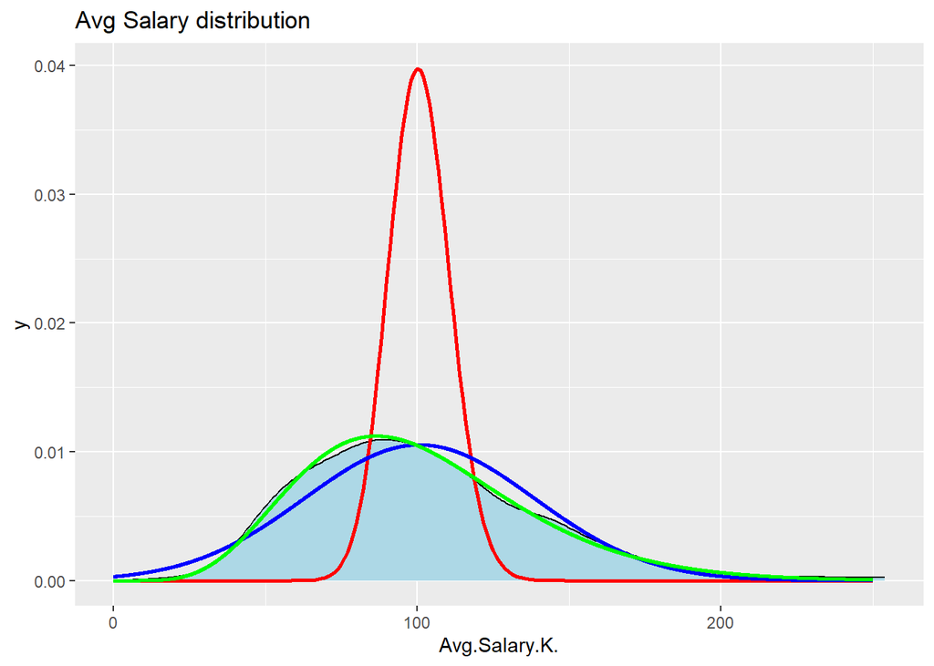

```r
lambda <- mean(Salary_data_Train$Avg.Salary.K.)
mean_val <- mean(Salary_data_Train$Avg.Salary.K.)
sd_val <- sd(Salary_data_Train$Avg.Salary.K.)

rate  = mean_val/var(Salary_data_Train$Avg.Salary.K.)
shape = rate * mean_val

xgrid = seq(0,250,0.1)

ggplot(Salary_data_Train, aes(Avg.Salary.K.)) +
  geom_density(fill = "lightblue") +
  geom_line(data = data.frame(x = 0:250, y = dpois(0:250, lambda = lambda)), aes(x = x, y = y), color = "red", linewidth = 1) +
  geom_line(data = data.frame(x = xgrid, y = dnorm(xgrid, mean = mean_val, sd = sd_val)),
            aes(x = x, y = y), color = "blue", linewidth = 1) +
  geom_line(data = data.frame(x = xgrid, y = dgamma(xgrid, shape = shape, rate = rate)),
            aes(x = x, y = y), color = "green", linewidth = 1) +
  ggtitle("Avg Salary distribution")
```

As can be observed, the Gamma distribution is the one that better fits our dataset, therefore, we would develop the GLM using it.

### 2.2. Relations between objective and rest of variables

Furthermore, we can plot the objective variable in terms of other ones to find relations. For example, here we observe how the salary distribution differs a lot from one type of job offer from another.

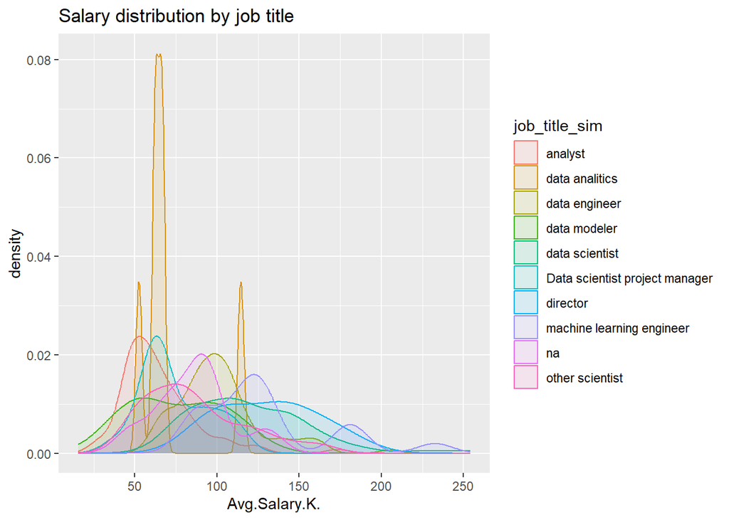

```r
ggplot(Salary_data_Train, aes(Avg.Salary.K.)) + geom_density(aes(group=job_title_sim, colour=job_title_sim, fill=job_title_sim), alpha=0.1) + ggtitle("Salary distribution by job title")
```

If we perform the box plot of the previous relationship, we better visualize how the offers for the ‘director’ position are the ones with biggest mean salary, or how the ‘data scientist’ offers are the ones with more variance of salaries.

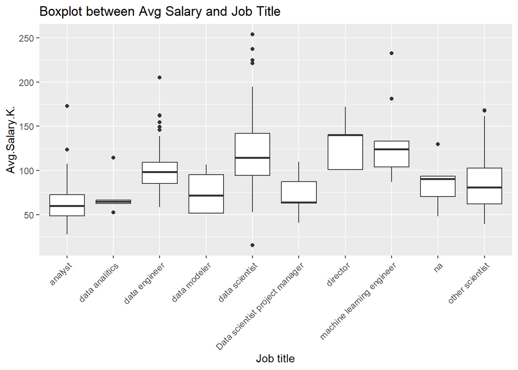

```r
ggplot(Salary_data_Train, aes(x = job_title_sim, y = Avg.Salary.K.)) +
  geom_boxplot() +
  labs(title = "Boxplot between Avg Salary and Job Title",
       x = "Job title",
       y = "Avg.Salary.K.")+
  theme(axis.text.x = element_text(angle = 45, hjust = 1))
```

Finally, we try to find some trend related with the rating of the companies and the mean salary, however, the scatter plot does not show any useful information.

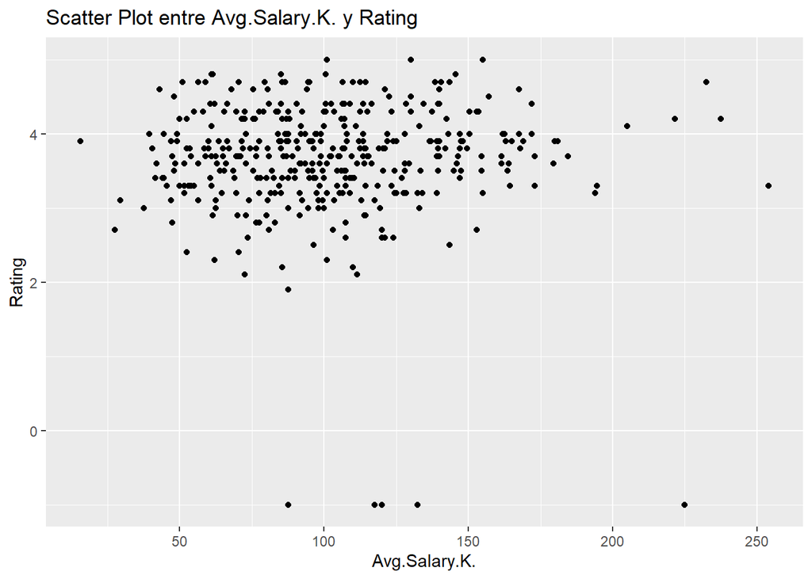

```r
ggplot(Salary_data_Train, aes(x = Avg.Salary.K., y = Rating)) +
  geom_point() +
  labs(title = "Scatter Plot entre Avg.Salary.K. y Rating",
       x = "Avg.Salary.K.",
       y = "Rating")
```

### 2.3. Correlations

Before starting modeling the predictor, we try to find the numeric (and binary) variables more correlated with the objective feature.

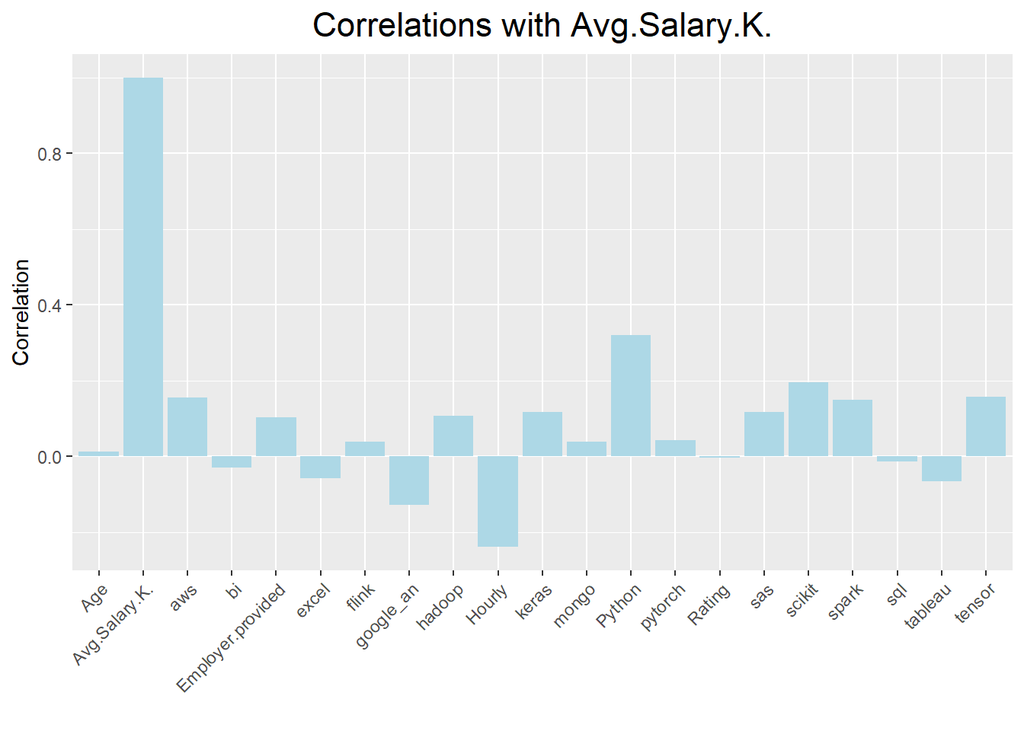

```r
# Calcular correlaciones
correlations <- cor(Salary_data_Train[, c("Age", "Rating", "Hourly", "Avg.Salary.K.", "Employer.provided", "Python", "spark", "aws", "excel", "sql", "sas", "keras", "pytorch", "scikit", "tensor", "hadoop", "tableau", "bi", "flink", "mongo", "google_an")])

# Extraer las correlaciones con la variable objetivo "Avg.Salary.K."
corr <- sort(correlations["Avg.Salary.K.",], decreasing = F)

# Crear un dataframe con las correlaciones
corr_df <- data.frame(variable = names(corr), correlation = corr)

# Crear el gráfico de barras
ggplot(corr_df, aes(x = variable, y = correlation)) +
  geom_bar(stat = "identity", fill = "lightblue") +
  labs(x = "", y = "Correlation", title = "Correlations with Avg.Salary.K.") +
  theme(plot.title = element_text(hjust = 0.5, size = rel(1.5)), axis.text.x = element_text(angle = 45, hjust = 1))
```

As with the previous dataset, this application would not be easy as most of the variables does not have any correlation with the objective one. However, we can highlight the values of ‘scikit’, ‘Hourly’ and ‘Python’.

## 3. Model development

### 3.1. Benchmark

Following the same criteria as with the previous application, in order to develop our model, we must first set the benchmark from where we would try to improve the prediction RMSE, or at least, get as close as possible.

```r
bench_glm = glm(Avg.Salary.K. ~ 1 , family = Gamma, data = Salary_data_Train)
#summary(bench_glm)

pred_bench_glm= predict(bench_glm, newdata= Salary_data_Test)

#Let's know validate the predictions, calculating R^2 in the testing set

# Evaluate performance on the test set
RMSE_test <- sqrt(mean((pred_bench_glm - Salary_data_Test$Avg.Salary.K.)^2))
cat("RMSE on test set:", RMSE_test, "\n")
```

```
## RMSE on test set: 110.9553
```

### 3.2. Developing the model

We would make a first approach, in order to evaluate the marginal effects of each variable into the model. Later, we would try to choose the best variables to define the final model. As we can observed, with this complex model we have reached $R^2= 0.39$ and $RMSE= 110.95$, so, by using all the variables, we have many information but also more noise, so RMSE is similar to benchmark.

```r
## First glm
first_glm = glm(Avg.Salary.K. ~ job_title_sim+ Rating + Hourly + Employer.provided + Python + spark + aws + excel + sql + sas + keras + pytorch + scikit + tensor + hadoop + tableau + bi + flink + mongo + google_an + Size + Type.of.ownership + Sector + Revenue+ Job.Location + Age, family = Gamma, data = Salary_data_Train)
#summary(first_glm)

pred_f_glm= predict(first_glm, newdata= Salary_data_Test)

#Let's know validate the predictions, calculating R^2 in the testing set

# Evaluate performance on the test set
R2_test <- cor(pred_f_glm, Salary_data_Test$Avg.Salary.K.)^2
RMSE_test <- sqrt(mean((pred_f_glm - Salary_data_Test$Avg.Salary.K.)^2))

cat("R-squared on test set:", R2_test, "\n")
```

```
## R-squared on test set: 0.3925165
```

```r
cat("RMSE on test set:", RMSE_test, "\n")
```

```
## RMSE on test set: 110.9554
```

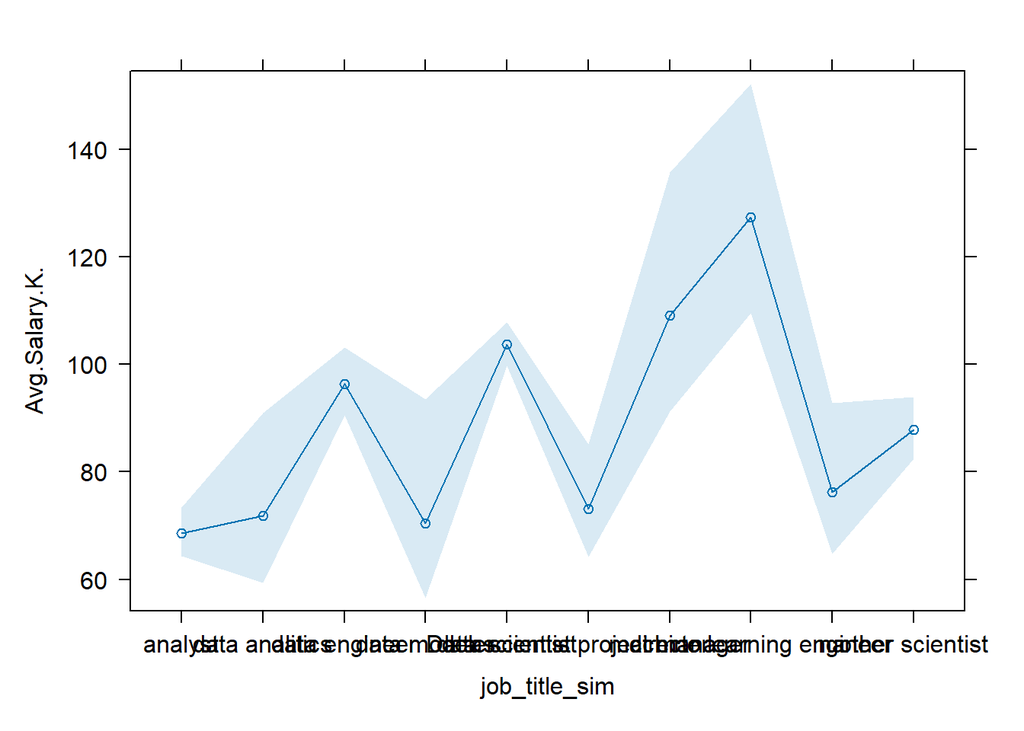

```r
variables = list("job_title_sim", "Rating", "Hourly", "Employer.provided" ,"Python" ,"spark", "aws" ,"excel", "sql" , "sas" , "keras" , "pytorch" , "scikit" ,"tensor" ,"hadoop" , "tableau" , "bi" , "flink" , "mongo" , "google_an", "Size", "Type.of.ownership",  "Sector",  "Revenue",  "Job.Location" , "Age")

#job_title_sim
plot(effect(variables[[1]], first_glm), ci.style="band", rescale.axis=FALSE, multiline=TRUE, ylab="Avg.Salary.K.", rug=FALSE, main="")
```

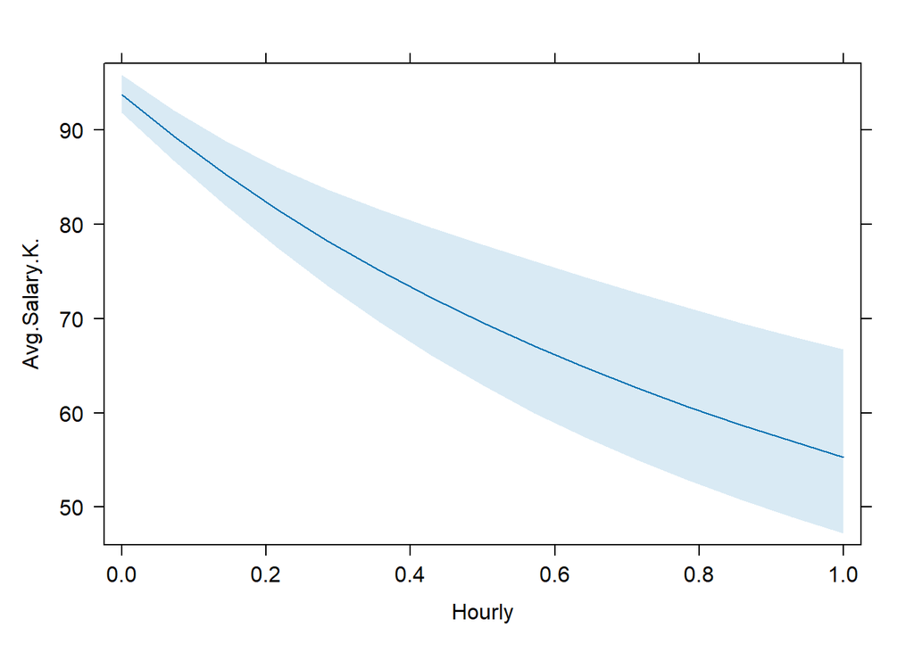

```r
#Hourly
plot(effect(variables[[3]], first_glm), ci.style="band", rescale.axis=FALSE, multiline=TRUE, ylab="Avg.Salary.K.", rug=FALSE, main="")
```

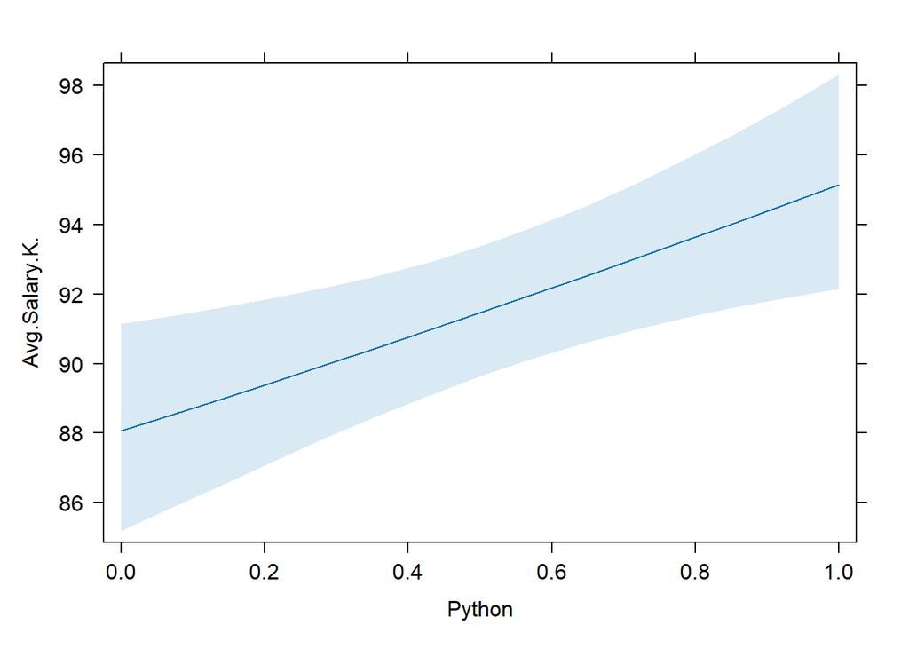

```r
#Python
plot(effect(variables[[5]], first_glm), ci.style="band", rescale.axis=FALSE, multiline=TRUE, ylab="Avg.Salary.K.", rug=FALSE, main="")
```

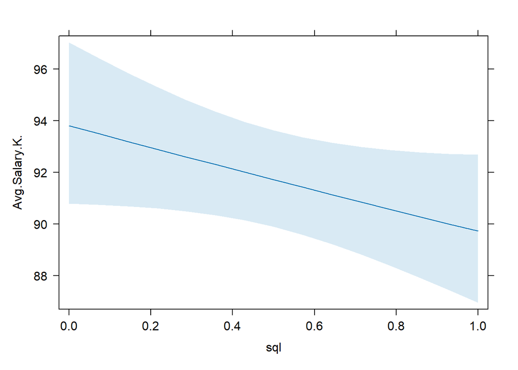

```r
#sql
plot(effect(variables[[9]], first_glm), ci.style="band", rescale.axis=FALSE, multiline=TRUE, ylab="Avg.Salary.K.", rug=FALSE, main="")
```

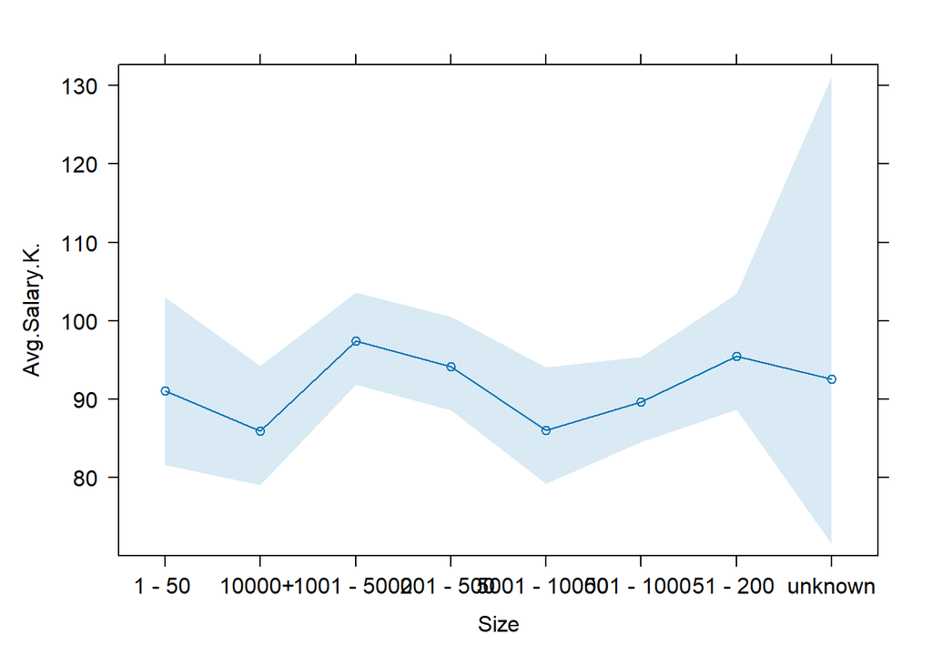

```r
#Size
plot(effect(variables[[21]], first_glm), ci.style="band", rescale.axis=FALSE, multiline=TRUE, ylab="Avg.Salary.K.", rug=FALSE, main="")
```

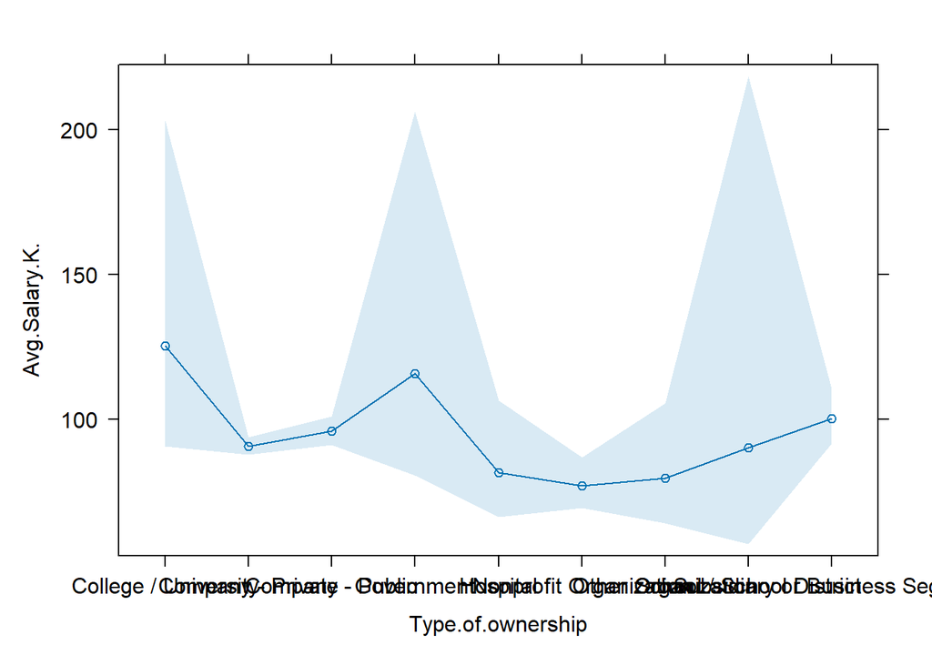

```r
#Type.of.ownership
plot(effect(variables[[22]], first_glm), ci.style="band", rescale.axis=FALSE, multiline=TRUE, ylab="Avg.Salary.K.", rug=FALSE, main="")
```